[figure not shown]

# Analysis and Prediction of Movie Data from IMDB

# 1. Introduction

Each year, the movie industry produces more movies, higher-budget movies, and more genres of media compete for audience attention. Between 2000 and 2010, only 36% of movies had profitable box-office returns. Therefore, missing an opportunity to make a commercia success movie has never been more costly than ever. And every decision the production company make has to takes more than ever into count.

Both imdb.com and tmdb.com are websites that serve as online databases of world film industry. Those websites contain a large amount of public data on films over the past few decades. Especially in the past few years, this kind of rating website has become many audiences’ first choice to examine the quality of movies. In addition to gaining tremendous profit commercially from a commercial success movie, a “great” movie also entertains the audience, and may even improve an individual’s perception.

By examining the historical data from thousands of movies over several decades, we are able to get statistically meaningful results that may help provide recommendations for the industry. As the saying goes, knowledge is power, and data analytics gives us the ability to turn raw data into valuable knowledge. However, is a highly-rated movie necessarily mean to be a commercial success movie? That what we are going to discuss throughout this project.

# 2. Prepartion & Data Collection

## 2.1 Required Library

We need to use Python 3 along with several external libraries: pandas, numpy, matplotlib, scikit-learn, seaborn, and etc.

```python
import json,requests
from bs4 import BeautifulSoup
import lxml
import numpy as np
from numpy import array
import pandas as pd
import datetime
import re
import statsmodels.formula.api as sm
from pandas.io.json import json_normalize
from ast import literal_eval
import matplotlib.pyplot as plt
import seaborn as sns
from scipy import stats
import random
from sklearn.preprocessing import OneHotEncoder
from sklearn.preprocessing import LabelEncoder
from sklearn.datasets import load_iris
from sklearn.ensemble import RandomForestRegressor
from sklearn.ensemble import AdaBoostRegressor
from sklearn.datasets import make_classification
from sklearn import tree
from IPython.display import Image
import pydotplus
```

## 2.2 Load Data

We need two data set for this project. One is from IMDB.com containing movie rating score, IMDB movie id and number of valid votes. The other dataset is from TMDB.com containing budget, cast, director and etc.

```python
file = 'tmdb-movies-imdb.csv'
df_tmdb = pd.read_csv(file)
df_tmdb.drop(columns=['homepage','revenue_adj','budget_adj', 'tagline', 'overview','vote_count','vote_average',\
                      ], axis = 1, inplace = True)
file = 'title.ratings.tsv'
df_imdb_rating = pd.read_csv(file, delimiter = '\t')
df_imdb_rating.columns = ['imdb_id', 'imdb_rating', 'imdb_votes']
```

## 2.3 Data Cleansing & Data Munging

We need two data set for this project. One is from IMDB.com containing movie rating score, IMDB movie id and number of valid votes. The other dataset is from TMDB.com containing budget, cast, director and etc.

```python
df2 = df_tmdb.merge(df_imdb_rating, how = "inner", on = "imdb_id")
#df2 = df2[df2.release_year>=2000]
df2 = df2.drop_duplicates()
df2.rename(columns={'original_title':'title'}, inplace=True)
df2.rename(columns={'release_year':'year'}, inplace=True)
```

```python
print(df2.columns)
```

```
Index(['id', 'imdb_id', 'popularity', 'budget', 'revenue', 'title', 'cast',
       'director', 'keywords', 'runtime', 'genres', 'production_companies',
       'release_date', 'year', 'imdb_rating', 'imdb_votes'],
      dtype='object')
```

Obviously, the dataset we got after merging has some redundant columns. The “id” and “imdb_id” columns will not help us analyze any data; therefore, they need to be dropped. Some columns are presented in array forms with raw string datatype, we need to store them in a list using split method.

Considering that we will make a prediction of IMDB ratings, movies with very limited votes are not very reliable, therefore, we drop those movies whose votes are less than 50. The dataset included some movies which are lacking budget or revenue data. When we look into those movies, we found that it was a common case for individual movies who do not have access to release movies in theaters. Since our hypothesis needs to count revenue and budget factors, we decided to drop those movies lacking budget and revenue data and those whose revenue and budget are less than $5000.

```python
df2['cast'] = df2['cast'].str.split('|')
df2['keywords'] = df2['keywords'].str.split('|')
df2['genres'] = df2['genres'].str.split('|')
df2['production_companies'] = df2['production_companies'].str.split('|')
df2.drop(columns=['id','imdb_id'], axis = 1, inplace = True)
df2['month'] = pd.to_datetime(df2['release_date']).apply(lambda x: x.month)
df2['date'] = pd.to_datetime(df2['release_date']).apply(lambda x: x.day)
df2.drop(columns=['release_date'], axis = 1, inplace = True)
df2 = df2[['title', 'director', 'cast', 'genres', 'runtime', 'keywords', 'production_companies', \
        'popularity', \
        'year', 'month', 'date','budget', 'revenue', 'imdb_rating', 'imdb_votes']]
df2 = df2.dropna()
df2 = df2[(df2.imdb_votes>=50) & (df2.budget >= 5000) & (df2.revenue >= 5000) & (df2.imdb_rating >= 3)]
df2.index = np.arange(1, len(df2)+1)
df0 = df2.copy()
df0['profit'] = df0['revenue'] - df0['budget']
df2.describe()
df2.head()
```

|  | title | director | cast | genres | runtime | keywords | production_companies | popularity | year | month | date | budget | revenue | imdb_rating | imdb_votes |
| --- | --- | --- | --- | --- | --- | --- | --- | --- | --- | --- | --- | --- | --- | --- | --- |
| 1 | Jurassic World | Colin Trevorrow | [Chris Pratt, Bryce Dallas Howard, Irrfan Khan... | [Action, Adventure, Science Fiction, Thriller] | 124 | [monster, dna, tyrannosaurus rex, velociraptor... | [Universal Studios, Amblin Entertainment, Lege... | 32.985763 | 2015 | 6 | 9 | 150000000 | 1513528810 | 7.0 | 541582 |
| 2 | Mad Max: Fury Road | George Miller | [Tom Hardy, Charlize Theron, Hugh Keays-Byrne,... | [Action, Adventure, Science Fiction, Thriller] | 120 | [future, chase, post-apocalyptic, dystopia, au... | [Village Roadshow Pictures, Kennedy Miller Pro... | 28.419936 | 2015 | 5 | 13 | 150000000 | 378436354 | 8.1 | 785272 |
| 3 | Insurgent | Robert Schwentke | [Shailene Woodley, Theo James, Kate Winslet, A... | [Adventure, Science Fiction, Thriller] | 119 | [based on novel, revolution, dystopia, sequel,... | [Summit Entertainment, Mandeville Films, Red W... | 13.112507 | 2015 | 3 | 18 | 110000000 | 295238201 | 6.2 | 200612 |
| 4 | Star Wars: The Force Awakens | J.J. Abrams | [Harrison Ford, Mark Hamill, Carrie Fisher, Ad... | [Action, Adventure, Science Fiction, Fantasy] | 136 | [android, spaceship, jedi, space opera, 3d] | [Lucasfilm, Truenorth Productions, Bad Robot] | 11.173104 | 2015 | 12 | 15 | 200000000 | 2068178225 | 8.0 | 787487 |
| 5 | Furious 7 | James Wan | [Vin Diesel, Paul Walker, Jason Statham, Miche... | [Action, Crime, Thriller] | 137 | [car race, speed, revenge, suspense, car] | [Universal Pictures, Original Film, Media Righ... | 9.335014 | 2015 | 4 | 1 | 190000000 | 1506249360 | 7.2 | 336174 |

Considering the inflation rate and many other factors such as global economic policy, the development of production technologies, we decided to only make analysis from 2000 to 2015. Otherwise, the revenue and budget could be largely affected by various factors which we do not have access from this dataset. Prior to that, the plot below shows the number of movies released by year that we took in consideration. Movie production exploded after year 1990.

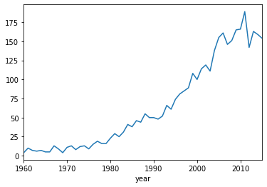

```python
data_groupby_year = df2.groupby(['year'])['title'].count()
production_trend = data_groupby_year.plot()
```

```python
df2 = df2[df2.year>=2000]
df2.index = np.arange(1, len(df2)+1)
```

# 3. Data Visualization & Data Analysis

## 3.1 Correlation Study

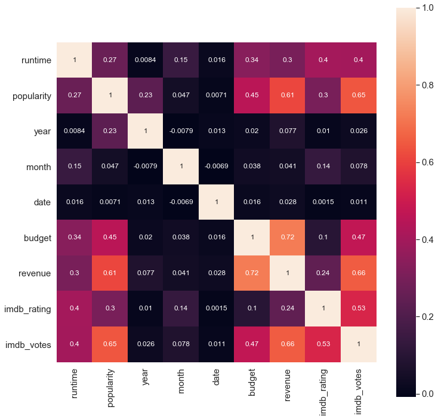

```python
sns.set(rc={
            'axes.labelsize':30,
            'figure.figsize':(12, 12),
            'xtick.labelsize':15,
            'ytick.labelsize':15})
corrmap = sns.heatmap(df2.corr(), annot=True, vmax=1, square=True )
```

By looking at this heatmap; popularity, votes, and budget are all strongly correlated with revenue. However, popularity and votes are both dependent variables which are unmeasurable before production. As for IMDB rating, only votes are strongly correlated with it, which is also an unmeasurable dependent data. Runtime is moderately correlated with rating. Nevertheless, in real world situation, runtime is quite unsure until casting is finished. It is very unlikely to make a prediction of IMDB rating among those data. But we do still have some categorical data left.

## 3.2 Successful Movies Based on Rating and Revenue

### 3.2.1 Top 20 Movies Based on Revenue

```python
df_top_revenue = df2.sort_values('revenue', ascending=False).head(20)
df_top_revenue.index = np.arange(1, len(df_top_revenue)+1)
df_top_revenue['roi'] = (df_top_revenue['revenue']-df_top_revenue['budget']) / df_top_revenue['budget']
df_top_revenue
```

|  | title | director | cast | genres | runtime | keywords | production_companies | popularity | year | month | date | budget | revenue | imdb_rating | imdb_votes | roi |
| --- | --- | --- | --- | --- | --- | --- | --- | --- | --- | --- | --- | --- | --- | --- | --- | --- |
| 1 | Avatar | James Cameron | [Sam Worthington, Zoe Saldana, Sigourney Weave... | [Action, Adventure, Fantasy, Science Fiction] | 162 | [culture clash, future, space war, space colon... | [Ingenious Film Partners, Twentieth Century Fo... | 9.432768 | 2009 | 12 | 10 | 237000000 | 2781505847 | 7.8 | 1049470 | 10.736312 |
| 2 | Star Wars: The Force Awakens | J.J. Abrams | [Harrison Ford, Mark Hamill, Carrie Fisher, Ad... | [Action, Adventure, Science Fiction, Fantasy] | 136 | [android, spaceship, jedi, space opera, 3d] | [Lucasfilm, Truenorth Productions, Bad Robot] | 11.173104 | 2015 | 12 | 15 | 200000000 | 2068178225 | 8.0 | 787487 | 9.340891 |
| 3 | The Avengers | Joss Whedon | [Robert Downey Jr., Chris Evans, Mark Ruffalo,... | [Science Fiction, Action, Adventure] | 143 | [new york, shield, marvel comic, comic, superh... | [Marvel Studios] | 7.637767 | 2012 | 4 | 25 | 220000000 | 1519557910 | 8.1 | 1188366 | 5.907081 |
| 4 | Jurassic World | Colin Trevorrow | [Chris Pratt, Bryce Dallas Howard, Irrfan Khan... | [Action, Adventure, Science Fiction, Thriller] | 124 | [monster, dna, tyrannosaurus rex, velociraptor... | [Universal Studios, Amblin Entertainment, Lege... | 32.985763 | 2015 | 6 | 9 | 150000000 | 1513528810 | 7.0 | 541582 | 9.090192 |
| 5 | Furious 7 | James Wan | [Vin Diesel, Paul Walker, Jason Statham, Miche... | [Action, Crime, Thriller] | 137 | [car race, speed, revenge, suspense, car] | [Universal Pictures, Original Film, Media Righ... | 9.335014 | 2015 | 4 | 1 | 190000000 | 1506249360 | 7.2 | 336174 | 6.927628 |
| 6 | Avengers: Age of Ultron | Joss Whedon | [Robert Downey Jr., Chris Hemsworth, Mark Ruff... | [Action, Adventure, Science Fiction] | 141 | [marvel comic, comic, sequel, superhero, vision] | [Marvel Studios, Prime Focus, Revolution Sun S... | 5.944927 | 2015 | 4 | 22 | 280000000 | 1405035767 | 7.3 | 670849 | 4.017985 |
| 7 | Harry Potter and the Deathly Hallows: Part 2 | David Yates | [Daniel Radcliffe, Rupert Grint, Emma Watson, ... | [Adventure, Family, Fantasy] | 130 | [self sacrifice, magic, frog, sorcerer, school] | [Warner Bros., Heyday Films, Moving Picture Co... | 5.711315 | 2011 | 7 | 7 | 125000000 | 1327817822 | 8.1 | 695191 | 9.622543 |
| 8 | Frozen | Chris Buck\|Jennifer Lee | [Kristen Bell, Idina Menzel, Jonathan Groff, J... | [Animation, Adventure, Family] | 102 | [queen, musical, princess, betrayal, snowman] | [Walt Disney Pictures, Walt Disney Animation S... | 6.112766 | 2013 | 11 | 27 | 150000000 | 1274219009 | 7.5 | 519564 | 7.494793 |
| 9 | Iron Man 3 | Shane Black | [Robert Downey Jr., Gwyneth Paltrow, Guy Pearc... | [Action, Adventure, Science Fiction] | 130 | [terrorist, war on terror, tennessee, malibu, ... | [Marvel Studios] | 4.946136 | 2013 | 4 | 18 | 200000000 | 1215439994 | 7.2 | 696934 | 5.077200 |
| 10 | Minions | Kyle Balda\|Pierre Coffin | [Sandra Bullock, Jon Hamm, Michael Keaton, All... | [Family, Animation, Adventure, Comedy] | 91 | [assistant, aftercreditsstinger, duringcredits... | [Universal Pictures, Illumination Entertainment] | 7.404165 | 2015 | 6 | 17 | 74000000 | 1156730962 | 6.4 | 195065 | 14.631499 |
| 11 | Transformers: Dark of the Moon | Michael Bay | [Shia LaBeouf, John Malkovich, Ken Jeong, Fran... | [Action, Science Fiction, Adventure] | 154 | [moon, spacecraft, traitor, bodyguard, fighter... | [Paramount Pictures, Di Bonaventura Pictures, ... | 0.760503 | 2011 | 6 | 28 | 195000000 | 1123746996 | 6.2 | 367296 | 4.762805 |
| 12 | The Lord of the Rings: The Return of the King | Peter Jackson | [Elijah Wood, Ian McKellen, Viggo Mortensen, L... | [Adventure, Fantasy, Action] | 201 | [elves, orcs, middle-earth (tolkien), based on... | [WingNut Films, New Line Cinema] | 7.122455 | 2003 | 12 | 1 | 94000000 | 1118888979 | 8.9 | 1502621 | 10.903074 |
| 13 | Skyfall | Sam Mendes | [Daniel Craig, Judi Dench, Javier Bardem, Ralp... | [Action, Adventure, Thriller] | 143 | [spy, secret agent, fall from height, sociopat... | [Columbia Pictures] | 5.603587 | 2012 | 10 | 25 | 200000000 | 1108561013 | 7.8 | 593776 | 4.542805 |
| 14 | The Dark Knight Rises | Christopher Nolan | [Christian Bale, Michael Caine, Gary Oldman, A... | [Action, Crime, Drama, Thriller] | 165 | [dc comics, crime fighter, terrorist, secret i... | [Legendary Pictures, Warner Bros., DC Entertai... | 6.591277 | 2012 | 7 | 16 | 250000000 | 1081041287 | 8.4 | 1393622 | 3.324165 |
| 15 | Pirates of the Caribbean: Dead Man's Chest | Gore Verbinski | [Johnny Depp, Orlando Bloom, Keira Knightley, ... | [Adventure, Fantasy, Action] | 151 | [witch, fortune teller, bondage, exotic island... | [Walt Disney Pictures, Jerry Bruckheimer Films... | 4.205992 | 2006 | 6 | 20 | 200000000 | 1065659812 | 7.3 | 615081 | 4.328299 |
| 16 | Toy Story 3 | Lee Unkrich | [Tom Hanks, Tim Allen, Ned Beatty, Joan Cusack... | [Animation, Family, Comedy] | 103 | [hostage, college, toy, barbie, animation] | [Walt Disney Pictures, Pixar Animation Studios] | 2.711136 | 2010 | 6 | 16 | 200000000 | 1063171911 | 8.3 | 690322 | 4.315860 |
| 17 | Alice in Wonderland | Tim Burton | [Mia Wasikowska, Johnny Depp, Anne Hathaway, H... | [Family, Fantasy, Adventure] | 108 | [based on novel, fictional place, queen, alice... | [Walt Disney Pictures, Team Todd, Tim Burton P... | 5.572950 | 2010 | 3 | 3 | 200000000 | 1025467110 | 6.5 | 359967 | 4.127336 |
| 18 | Pirates of the Caribbean: On Stranger Tides | Rob Marshall | [Johnny Depp, PenÃ©lope Cruz, Geoffrey Rush, I... | [Adventure, Action, Fantasy] | 136 | [sea, captain, mutiny, sword, prime minister] | [Walt Disney Pictures, Jerry Bruckheimer Films... | 4.955130 | 2011 | 5 | 11 | 380000000 | 1021683000 | 6.6 | 449315 | 1.688639 |
| 19 | The Hobbit: An Unexpected Journey | Peter Jackson | [Ian McKellen, Martin Freeman, Richard Armitag... | [Adventure, Fantasy, Action] | 169 | [riddle, elves, dwarves, orcs, middle-earth (t... | [WingNut Films, New Line Cinema, Metro-Goldwyn... | 4.218933 | 2012 | 11 | 26 | 250000000 | 1017003568 | 7.9 | 721111 | 3.068014 |
| 20 | The Dark Knight | Christopher Nolan | [Christian Bale, Michael Caine, Heath Ledger, ... | [Drama, Action, Crime, Thriller] | 152 | [dc comics, crime fighter, secret identity, sc... | [DC Comics, Legendary Pictures, Warner Bros., ... | 8.466668 | 2008 | 7 | 16 | 185000000 | 1001921825 | 9.0 | 2077141 | 4.415794 |

```python
def countNumber(column):
    count = dict()
    for row in column:
        for ele in row:
            if ele in count:
                count[ele] += 1
            else:
                count[ele] = 1
    return count
print(df_top_revenue.mean())
print(countNumber(df_top_revenue.genres))
```

```
runtime        1.389000e+02
popularity     7.544618e+00
year           2.011400e+03
month          7.150000e+00
date           1.565000e+01
budget         1.990000e+08
revenue        1.319770e+09
imdb_rating    7.575000e+00
imdb_votes     7.725467e+05
roi            6.416146e+00
dtype: float64
{'Action': 15, 'Adventure': 16, 'Fantasy': 8, 'Science Fiction': 7, 'Thriller': 5, 'Crime': 3, 'Family': 5, 'Animation': 3, 'Comedy': 2, 'Drama': 2}
```

The top 20 movies based on their revenue has an average budget over $199 million and an average ROI (Return on Investment) of 6.41, which are much higher than average movies. Another finding is that action, adventure, and fantasy are the most frequently seen movies among the top 20 list. We may want to ask, does those three genres necessarily mean high revenue? We will make further discuss in the later section.

### 3.2.2 Top 20 Movies Based on IMDB Rating

```python
df_top_rating = df2.sort_values('imdb_rating', ascending=False).head(20)
df_top_rating.index = np.arange(1, len(df_top_rating)+1)
df_top_rating['roi'] = (df_top_rating['revenue']-df_top_rating['budget']) / df_top_rating['budget']
df_top_rating
```

|  | title | director | cast | genres | runtime | keywords | production_companies | popularity | year | month | date | budget | revenue | imdb_rating | imdb_votes | roi |
| --- | --- | --- | --- | --- | --- | --- | --- | --- | --- | --- | --- | --- | --- | --- | --- | --- |
| 1 | The Dark Knight | Christopher Nolan | [Christian Bale, Michael Caine, Heath Ledger, ... | [Drama, Action, Crime, Thriller] | 152 | [dc comics, crime fighter, secret identity, sc... | [DC Comics, Legendary Pictures, Warner Bros., ... | 8.466668 | 2008 | 7 | 16 | 185000000 | 1001921825 | 9.0 | 2077141 | 4.415794 |
| 2 | The Lord of the Rings: The Return of the King | Peter Jackson | [Elijah Wood, Ian McKellen, Viggo Mortensen, L... | [Adventure, Fantasy, Action] | 201 | [elves, orcs, middle-earth (tolkien), based on... | [WingNut Films, New Line Cinema] | 7.122455 | 2003 | 12 | 1 | 94000000 | 1118888979 | 8.9 | 1502621 | 10.903074 |
| 3 | The Lord of the Rings: The Fellowship of the Ring | Peter Jackson | [Elijah Wood, Ian McKellen, Viggo Mortensen, L... | [Adventure, Fantasy, Action] | 178 | [elves, dwarves, orcs, middle-earth (tolkien),... | [WingNut Films, New Line Cinema, The Saul Zaen... | 8.575419 | 2001 | 12 | 18 | 93000000 | 871368364 | 8.8 | 1518401 | 8.369552 |
| 4 | Inception | Christopher Nolan | [Leonardo DiCaprio, Joseph Gordon-Levitt, Elle... | [Action, Thriller, Science Fiction, Mystery, A... | 148 | [loss of lover, dream, sleep, subconsciousness... | [Legendary Pictures, Warner Bros., Syncopy] | 9.363643 | 2010 | 7 | 14 | 160000000 | 825500000 | 8.8 | 1850687 | 4.159375 |
| 5 | The Lord of the Rings: The Two Towers | Peter Jackson | [Elijah Wood, Ian McKellen, Viggo Mortensen, L... | [Adventure, Fantasy, Action] | 179 | [elves, orcs, middle-earth (tolkien), hobbits,... | [WingNut Films, New Line Cinema, The Saul Zaen... | 8.095275 | 2002 | 12 | 18 | 79000000 | 926287400 | 8.7 | 1358877 | 10.725157 |
| 6 | Interstellar | Christopher Nolan | [Matthew McConaughey, Jessica Chastain, Anne H... | [Adventure, Drama, Science Fiction] | 169 | [saving the world, artificial intelligence, fa... | [Paramount Pictures, Legendary Pictures, Warne... | 24.949134 | 2014 | 11 | 5 | 165000000 | 621752480 | 8.6 | 1308557 | 2.768197 |
| 7 | Memento | Christopher Nolan | [Guy Pearce, Carrie-Anne Moss, Joe Pantoliano,... | [Mystery, Thriller] | 113 | [individual, insulin, tattoo, waitress, amnesia] | [Summit Entertainment, Newmarket Capital Group... | 3.095625 | 2000 | 10 | 11 | 9000000 | 39723096 | 8.5 | 1035423 | 3.413677 |
| 8 | Whiplash | Damien Chazelle | [Miles Teller, J.K. Simmons, Melissa Benoist, ... | [Drama, Music] | 105 | [jazz, obsession, conservatory, music teacher,... | [Bold Films, Blumhouse Productions, Right of W... | 4.780419 | 2014 | 10 | 10 | 3300000 | 13993093 | 8.5 | 621747 | 3.240331 |
| 9 | The Pianist | Roman Polanski | [Adrien Brody, Thomas Kretschmann, Frank Finla... | [Drama, War] | 150 | [individual, resistance, radio station, war cr... | [Bac Films, Canal+Polska, Heritage Films, Stud... | 2.364204 | 2002 | 9 | 24 | 35000000 | 120072577 | 8.5 | 647820 | 2.430645 |
| 10 | The Departed | Martin Scorsese | [Leonardo DiCaprio, Matt Damon, Jack Nicholson... | [Drama, Thriller, Crime] | 151 | [undercover, boston, police, friends, mafia] | [Vertigo Entertainment, Media Asia Films, Warn... | 2.819750 | 2006 | 10 | 5 | 90000000 | 289847354 | 8.5 | 1081549 | 2.220526 |
| 11 | The Prestige | Christopher Nolan | [Hugh Jackman, Christian Bale, Michael Caine, ... | [Drama, Mystery, Thriller] | 130 | [competition, secret, obsession, magic, dying ... | [Touchstone Pictures, Syncopy] | 2.582095 | 2006 | 10 | 19 | 40000000 | 109676311 | 8.5 | 1071908 | 1.741908 |
| 12 | Gladiator | Ridley Scott | [Russell Crowe, Joaquin Phoenix, Connie Nielse... | [Action, Drama, Adventure] | 155 | [rome, gladiator, roman empire, slavery, battl... | [DreamWorks SKG, Universal Pictures, Scott Fre... | 4.271452 | 2000 | 5 | 1 | 103000000 | 457640427 | 8.5 | 1219016 | 3.443111 |
| 13 | WALL·E | Andrew Stanton | [Ben Burtt, Elissa Knight, Jeff Garlin, Fred W... | [Animation, Family] | 98 | [future, garbage, plants, dystopia, lonelyness] | [Walt Disney Pictures, Pixar Animation Studios] | 5.678119 | 2008 | 6 | 22 | 180000000 | 521311860 | 8.4 | 912117 | 1.896177 |
| 14 | Django Unchained | Quentin Tarantino | [Jamie Foxx, Christoph Waltz, Leonardo DiCapri... | [Drama, Western] | 165 | [bounty hunter, hero, plantation, society, fri... | [Columbia Pictures, The Weinstein Company] | 5.944518 | 2012 | 12 | 25 | 100000000 | 425368238 | 8.4 | 1217590 | 3.253682 |
| 15 | The Dark Knight Rises | Christopher Nolan | [Christian Bale, Michael Caine, Gary Oldman, A... | [Action, Crime, Drama, Thriller] | 165 | [dc comics, crime fighter, terrorist, secret i... | [Legendary Pictures, Warner Bros., DC Entertai... | 6.591277 | 2012 | 7 | 16 | 250000000 | 1081041287 | 8.4 | 1393622 | 3.324165 |
| 16 | 3 Idiots | Rajkumar Hirani | [Aamir Khan, Kareena Kapoor, Madhavan, Sharman... | [Drama, Comedy, Romance] | 170 | [suicide, suicide attempt, college, friends, e... | [Vidhu Vinod Chopra Productions] | 0.816681 | 2009 | 12 | 23 | 9000000 | 70000000 | 8.4 | 302685 | 6.777778 |
| 17 | Inglourious Basterds | Quentin Tarantino | [Brad Pitt, Mélanie Laurent, Christoph Waltz,... | [Drama, Action, Thriller, War] | 153 | [paris, guerilla, cinema, self sacrifice, dyna... | [Universal Pictures, A Band Apart, Zehnte Babe... | 6.098027 | 2009 | 8 | 18 | 70000000 | 319131050 | 8.3 | 1125859 | 3.559015 |
| 18 | Requiem for a Dream | Darren Aronofsky | [Ellen Burstyn, Jared Leto, Jennifer Connelly,... | [Drama] | 102 | [drug addiction, junkie, heroin, speed, diet] | [Artisan Entertainment] | 1.050687 | 2000 | 10 | 27 | 4500000 | 7390108 | 8.3 | 703579 | 0.642246 |
| 19 | Eternal Sunshine of the Spotless Mind | Michel Gondry | [Jim Carrey, Kate Winslet, Elijah Wood, Mark R... | [Science Fiction, Drama, Romance] | 108 | [deja vu, lovesickness, jealousy, amnesia, los... | [Anonymous Content, This Is That Productions, ... | 3.863377 | 2004 | 3 | 19 | 20000000 | 72258126 | 8.3 | 829216 | 2.612906 |
| 20 | Toy Story 3 | Lee Unkrich | [Tom Hanks, Tim Allen, Ned Beatty, Joan Cusack... | [Animation, Family, Comedy] | 103 | [hostage, college, toy, barbie, animation] | [Walt Disney Pictures, Pixar Animation Studios] | 2.711136 | 2010 | 6 | 16 | 200000000 | 1063171911 | 8.3 | 690322 | 4.315860 |

```python
print(df_top_rating.mean())
print(countNumber(df_top_rating.genres))
```

```
runtime        1.447500e+02
popularity     5.961998e+00
year           2.006500e+03
month          8.950000e+00
date           1.540000e+01
budget         9.449000e+07
revenue        4.978172e+08
imdb_rating    8.530000e+00
imdb_votes     1.123437e+06
roi            4.210659e+00
dtype: float64
{'Drama': 13, 'Action': 8, 'Crime': 3, 'Thriller': 7, 'Adventure': 6, 'Fantasy': 3, 'Science Fiction': 3, 'Mystery': 3, 'Music': 1, 'War': 2, 'Animation': 2, 'Family': 2, 'Western': 1, 'Comedy': 2, 'Romance': 2}
```

The top 20 movies based on their IMDB rating has an average ROI (Return on Investment) of 4.21, which may be lower the previous list but are still much higher than average movies. The top 20 list here does not cover all years from 2000-2015. Therefore, we make a dataset that includes top 100 IMDB rated movies to see if those highly-rated movies tend to have a higher ROI. Also be aware that the distribution of genres from the top 20 list tend to have higher frequency on some genres such as drama.

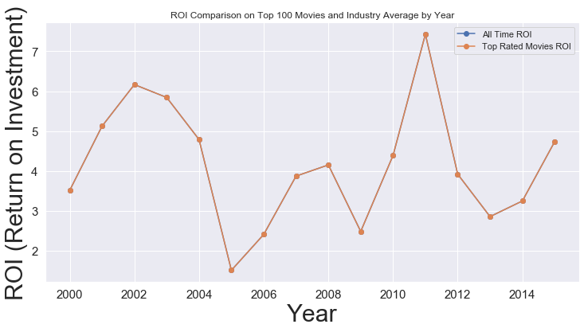

```python
df_rio_100 = df2.sort_values('imdb_rating', ascending=False).head(100)

df_rio_100 = df_rio_100.groupby('year')['budget','revenue'].sum()
df_rio_100['roi'] = (df_rio_100.revenue - df_rio_100.budget) / df_rio_100.budget

top_rated_year = df_rio_100.index.unique().tolist()
temp_roi_100 = df_rio_100[df_rio_100.index.isin(top_rated_year)]
df_rio_100['all_roi'] = temp_roi_100['roi']
plt.figure(figsize=(12,6))
plt.plot(top_rated_year, df_rio_100['all_roi'].tolist(), marker='o', label = 'All Time ROI')
plt.plot(top_rated_year, df_rio_100['roi'].tolist(), marker='o', label = 'Top Rated Movies ROI')
plt.xlabel("Year")
plt.ylabel("ROI (Return on Investment)")
plt.title("ROI Comparison on Top 100 Movies and Industry Average by Year")

plt.legend()
plt.show()
```

## 3.3 Budget, Revenue, and ROI Trend

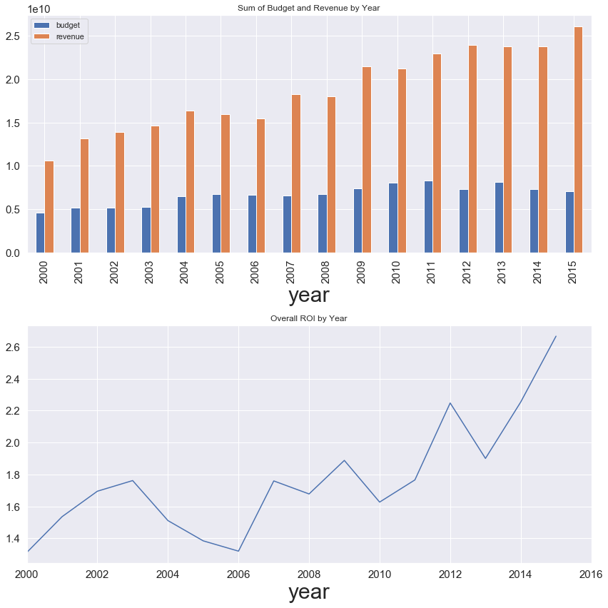

```python
df_roi = df2.groupby('year')['budget','revenue'].sum()
df_roi['roi'] = (df_roi.revenue - df_roi.budget) / df_roi.budget
fig, axes = plt.subplots(figsize=(12,12),ncols=1, nrows=2)
df_roi[['budget', 'revenue']].plot.bar(ax=axes[0],  title='Sum of Budget and Revenue by Year')
df_roi.roi.plot(ax=axes[1], title='Overall ROI by Year', xlim = (2000,2016))
fig.tight_layout()
```

## 3.4 What Does Movie Genres Impact

### 3.4.1 Frequency of Genres

```
<BarContainer object of 19 artists>
```

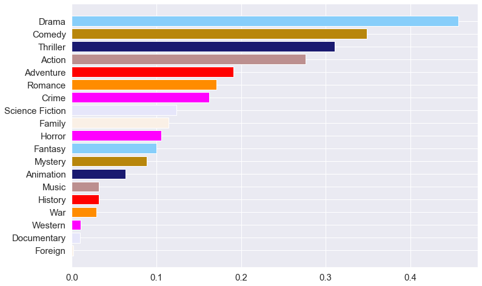

```python
genres = pd.Series(countNumber(df2.genres)).sort_values()
genres_avg = genres / len(df2)
plt.figure(figsize=(12,8))
all_colors = list(plt.cm.colors.cnames.keys())
random.seed(10)
c = random.choices(all_colors, k=10)
plt.barh(genres_avg.index, genres_avg, color = c)
```

### 3.4.2 Genres vs IMDB Rating

```python
df_by_genres = pd.DataFrame(0, index = genres.index, columns=['budget', 'revenue', 'rating'])
for i in range(1, len(df2)+1):
    for j in df2.genres[i]:
        df_by_genres.loc[j, 'budget'] += df2.revenue[i]
        df_by_genres.loc[j, 'revenue'] += df2.budget[i]
        df_by_genres.loc[j, 'rating'] += df2.imdb_rating[i]
df_by_genres = df_by_genres.div(genres.values, axis=0)
df_by_genres['roi'] = (df_by_genres['revenue'] - df_by_genres['budget']) / df_by_genres['budget']
```

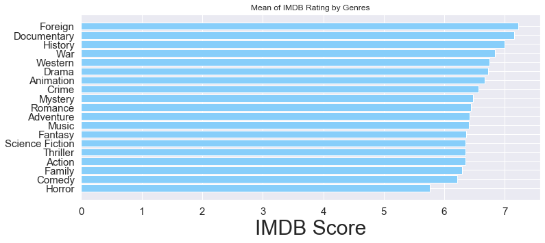

```python
df_by_genres = df_by_genres.sort_values('rating')
plt.figure(figsize=(12,5))
y_pos = np.arange(len(df_by_genres))
plt.barh( df_by_genres.index, df_by_genres.rating,align='center', color = 'lightskyblue')
plt.xlabel("IMDB Score")
plt.title("Mean of IMDB Rating by Genres")
plt.show()
```

The difference of movie ratings between genres cannot be ignored in terms of the rating percentages. While foreign movies have an average rating of 7.22 and horror movies have an average of 5.76, the average rating of foreign movies is 25%((7.22-5.76)/5.76) higher than horror movies. Therefore, when we want to make a prediction of IMDB rating prediction, it is better to take genres into count.

## 3.5 What Role Do Directors Play?

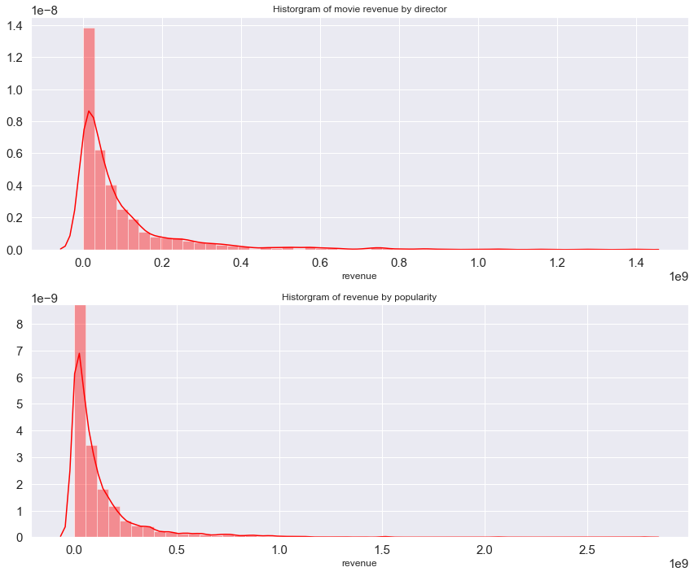

```python
revenue_of_director = df2.groupby('director').revenue.mean()
sns.set(rc={'figure.figsize':(12,6),
            'xtick.labelsize':15,
            'ytick.labelsize':15})
plt.figure(figsize=(12,10))

plt.subplot(2, 1, 1)
hito_revenue_director = sns.distplot(revenue_of_director, color = 'red')
hito_revenue_director.set_title('Historgram of movie revenue by director')
plt.subplot(2, 1, 2)
popularity_of_director = df2.groupby('popularity').revenue.mean()
hito_popularity_director = sns.distplot(popularity_of_director, color = 'red')
hito_popularity_director.set_title('Historgram of revenue by popularity')
plt.tight_layout()
```

Both distributions are long-tailed, very few directors have taken most market shares and attracted people’s attention. Companies typically tend to give those directors higher budget and more resources. In another word, industry lead directors tend to cooperate with more successful celebrities. Then how does casting affect the revenue of a movie?

## 3.6 How Does Casting Impact the Market?

Prior to making any plots, we need to understand that movie stars may have different contributions to the revenue and rating of a movie. If we keep using the same method as the genres one, the result may come out showing that a person who tend to play more as a supporting role has higher total box office than the person who spend most of the time playing the leading role. Therefore, we try to give a different coefficient to each casting member. In addition, we do not take animation casting into count.

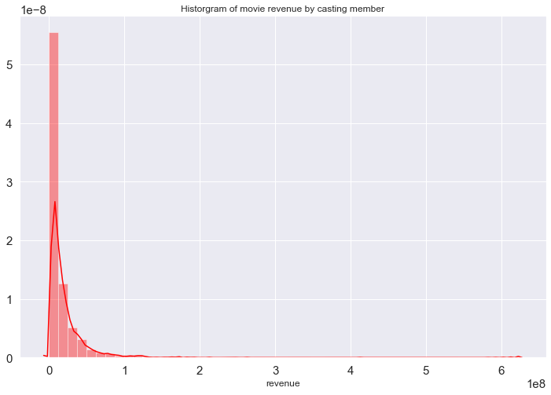

```python
temp_2 = df2[~df2.genres.str.contains('Animation', regex=False)].reset_index(drop='True')
actors = pd.Series(countNumber(temp_2.cast)).sort_values()
movies_by_cast = pd.DataFrame(0, index= actors.index, columns=['revenue', 'vote'])
r4 = [0.4, 0.3, 0.2, 0.1]
r3 = [0.45, 0.3, 0.25]
r2 = [0.55, 0.45]
r1 = [1]
r = [r1, r2, r3, r4]
for i in range(len(temp_2)):
    actorlist = temp_2.cast[i][0:4]
    for j in range(len(actorlist)):
        movies_by_cast.loc[actorlist[j], 'revenue'] += temp_2.revenue[i] * r[len(actorlist)-1][j]
        movies_by_cast.loc[actorlist[j], 'vote'] += temp_2.imdb_rating[i]
movies_by_cast = movies_by_cast.div(actors.values, axis=0)

plt.figure(figsize=(12,8))
histo_revenue_cast = sns.distplot(movies_by_cast.revenue, color = 'red')
histo_revenue_cast.set_title('Historgram of movie revenue by casting member')
```

Again, another heavy-tailed distribution. It is amazing how revenue by actor is distributed. Very small portion of actors took most market share. We would like to bring up a question: If genres, directors, and casting crew have a huge impact on revenue, what if we make a prediction of IMDB rating out of these categorical data?

## 3.7 IMDB Raing by Year

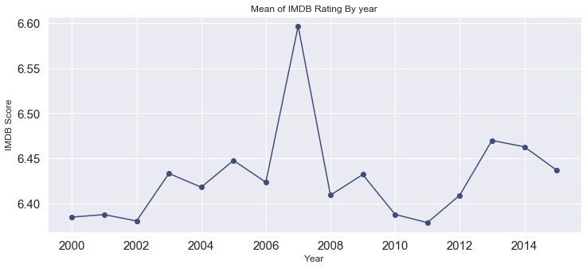

```python
rating_average = df2.groupby('year').imdb_rating.mean()
year = df2.sort_values('year', ascending=False).year.unique().tolist()
plt.figure(figsize=(12,5))
plt.plot(rating_average.index, rating_average, marker='o', label = 'All Time ROI', color = '#3D4E7C')
plt.xlim = (2000,2015)
plt.xlabel("Year")
plt.ylabel("IMDB Score")
plt.title("Mean of IMDB Rating By year")
plt.show()
```

There does not seem to have a trend of movie ratings by year.

# 4 IMDB Rating Prediction

Predicting the global box office of movies would be very complicated. And yet companies can hardly make a universal model for all movies. In reality, the final global box office may over-perform or under-perform due to various unpredictable factors. However, predicting movie ratings would be more achievable.

## 4.1 One-Hot Encoding on Categorical Data

From our analysis above. We observed that we need to take some categorical data into count, which includes casts, production companies and directors. To convert categorical data into quantitative data, we can use one-hot encoding technique to encode them.

```python
df3 = df2.copy()
from sklearn.preprocessing import StandardScaler
from sklearn.model_selection import train_test_split
from sklearn.neighbors import KNeighborsClassifier
from sklearn.linear_model import LogisticRegression
from sklearn.preprocessing import MultiLabelBinarizer
X = df3[['budget','month','runtime','popularity','imdb_votes','cast','director','genres','production_companies']]
X.index = np.arange(0, len(X))
y = df3['imdb_rating']
y.index = np.arange(0, len(y))
one_hot_multi = MultiLabelBinarizer()
label_encoder = LabelEncoder()
one_hot_single = OneHotEncoder(sparse=False)
temp = (pd.DataFrame(one_hot_multi.fit_transform(X.cast)))
temp = pd.concat([temp, (pd.DataFrame(one_hot_multi.fit_transform(X.genres)))], axis=1)
temp = pd.concat([temp, (pd.DataFrame(one_hot_multi.fit_transform(X.production_companies)))], axis=1)

label_encoded = label_encoder.fit_transform(X.director)
onehot_encoder_single = OneHotEncoder(sparse=False,categories='auto')
temp = pd.concat([temp, pd.DataFrame(onehot_encoder_single.fit_transform(label_encoded.reshape(-1,1)))], axis=1)
```

## 4.2 Quatitative Data

In addition to the categorical data, we need some quatitative data to make our model more accurate. The number of votes is a dependente variable which relays on various factors. Therefore, predicting imdb score using imdb_votes will not be applicable in reality. From the previous analysis, we can see that runtime, month, budgete and popularity are all correlated to the IMDB ratings. Therefore, we need to add these vairables into count.

```python
temp['runtime']=X['runtime']
temp['month']=X['month']
temp['budget']=X['budget']
temp['popularity']=X['popularity']
```

## 4.3 Random Forest Prediction

I will use 80% of the data as the training set and the rest 20% of the data as the testing set. Sklearn has pre-defined function for random forest. Since some of the data is continuous, RandomForestRegressor will be applied.

```python
X_train, X_test, y_train, y_test = train_test_split(temp, y, test_size=0.2, random_state=33)
clf = RandomForestRegressor(n_estimators=100)
clf = clf.fit(X_train,y_train)
clf.score(X_test,y_test)
```

```
0.624973517530951
```

```python
clf.score(X_train,y_train)
```

```
0.8874268534040877
```

[figure not shown]

# 5 Conclusion and Further Exploration